# Data Science 2401 - Final Project

Placido Garay

2023-11-27

# Introduction

[Sport Dataset Link](https://data.world/coreyhermanson/toughest-sport-by-skill)

This data set conducts 60 sports that basis their athleticism in 10 categories. The 10 categories is then totaled and ranked based on how difficult the sport is by skill. The data was calculated by a group of 8 sports scientists from the United States Olympic Committee. There isn’t a definitive timeline of when the data was calculated, but was published in 2017.

# Questions to ask

- What and how does the unfiltered data-set explain itself?
- How does each sport rank respically within their own sport category that include:
- 1. Toughest Snow/Ice Sports
- 2. Toughest Adventure Sports
- 3. Toughest Water Sports
- 4. Toughest Team Sport
- 5. Toughest Individual Sport
- For each data-set, what is the max,min and mean of difficulty?
- What are the easiest sports ranked by difficulty?

# Packages Used

```r
#used this to tidy up the data
library(tidyverse)
#used for data manipulation
library(dplyr)
#used for data visualization
library(ggplot2)
#Scroll boxes
library(kableExtra)
```

# Unfiltered Dataset

```r
glimpse(toughestsport)
```

```
## Rows: 60
## Columns: 13
## $ SPORT <chr> "Boxing", "Ice Hockey", "Football", "Basketball", "Wrestling", "…
## $ END   <dbl> 8.63, 7.25, 5.38, 7.38, 6.63, 5.00, 7.25, 5.38, 4.63, 7.75, 5.13…
## $ STR   <dbl> 8.13, 7.13, 8.63, 6.25, 8.38, 5.88, 5.13, 6.13, 5.75, 4.50, 5.25…
## $ PWR   <dbl> 8.63, 7.88, 8.13, 6.50, 7.13, 7.75, 7.13, 6.63, 7.63, 5.13, 6.00…
## $ SPD   <dbl> 6.38, 7.75, 7.13, 7.25, 5.13, 6.38, 6.75, 5.00, 6.50, 7.25, 7.38…
## $ AGI   <dbl> 6.25, 7.63, 6.38, 8.13, 6.38, 6.00, 7.75, 6.38, 6.75, 8.25, 6.13…
## $ FLX   <dbl> 4.38, 4.88, 4.38, 5.63, 7.50, 7.00, 5.63, 10.00, 4.75, 4.75, 5.6…
## $ NER   <dbl> 8.88, 6.00, 7.25, 4.13, 5.00, 6.63, 3.00, 7.50, 5.13, 3.63, 8.38…
## $ DUR   <dbl> 8.50, 8.25, 8.50, 7.75, 6.75, 5.88, 5.00, 6.88, 5.63, 6.25, 6.00…
## $ HAN   <dbl> 7.00, 7.50, 5.50, 7.50, 4.25, 6.00, 8.38, 4.50, 9.25, 6.50, 5.13…
## $ ANA   <dbl> 5.63, 7.50, 7.13, 7.38, 6.38, 6.88, 6.75, 4.13, 6.25, 7.50, 5.63…
## $ TOTAL <dbl> 72.375, 71.750, 68.375, 67.875, 63.500, 63.375, 62.750, 62.500, …
## $ RANK  <dbl> 1, 2, 3, 4, 5, 6, 7, 8, 9, 10, 11, 11, 13, 14, 15, 16, 17, 17, 1…
```

# Key Terms

- END (Endurance): The ability to continue to perform a skill or action for long periods of time.
- STR (Strength): The ability to produce force.
- PWR (Power): The ability to produce strength in the shortest possible time.
- SPD (Speed): The ability to move quickly.
- AGI(Agility): The ability to change direction quickly.
- FLX (Flexibility): The ability to stretch the joints across a large range of motion.
- NER (Nerve): The ability to overcome fear.
- DUR(Durability): The ability to withstand physical punishment over a long period of time.
- HAN (Hand-Eye Coordination): The ability to react quickly to sensory perception.
- ANA (Analytic Aptitude): The ability to evaluate and react appropriately to strategic situations.

# Calculations

- Total # of sports: 60
- Categories (Skills): 10
- Out of the 10 categories, skills are arranged from a 1-10 scale based on the demands for each sport.
- Total # of skills: All 10 categories are added and are based individually for each sport.
- Rank: All 60 sports are ranked based on their degree of difficulty total amount.

# Unfiltered Plot/Data

| SPORT | END | STR | PWR | SPD | AGI | FLX | NER | DUR | HAN | ANA | TOTAL | RANK |
| --- | --- | --- | --- | --- | --- | --- | --- | --- | --- | --- | --- | --- |
| Boxing | 8.63 | 8.13 | 8.63 | 6.38 | 6.25 | 4.38 | 8.88 | 8.50 | 7.00 | 5.63 | 72.375 | 1 |
| Ice Hockey | 7.25 | 7.13 | 7.88 | 7.75 | 7.63 | 4.88 | 6.00 | 8.25 | 7.50 | 7.50 | 71.750 | 2 |
| Football | 5.38 | 8.63 | 8.13 | 7.13 | 6.38 | 4.38 | 7.25 | 8.50 | 5.50 | 7.13 | 68.375 | 3 |
| Basketball | 7.38 | 6.25 | 6.50 | 7.25 | 8.13 | 5.63 | 4.13 | 7.75 | 7.50 | 7.38 | 67.875 | 4 |
| Wrestling | 6.63 | 8.38 | 7.13 | 5.13 | 6.38 | 7.50 | 5.00 | 6.75 | 4.25 | 6.38 | 63.500 | 5 |
| Martial Arts | 5.00 | 5.88 | 7.75 | 6.38 | 6.00 | 7.00 | 6.63 | 5.88 | 6.00 | 6.88 | 63.375 | 6 |
| Tennis | 7.25 | 5.13 | 7.13 | 6.75 | 7.75 | 5.63 | 3.00 | 5.00 | 8.38 | 6.75 | 62.750 | 7 |
| Gymnastics | 5.38 | 6.13 | 6.63 | 5.00 | 6.38 | 10.00 | 7.50 | 6.88 | 4.50 | 4.13 | 62.500 | 8 |
| Baseball/Softball | 4.63 | 5.75 | 7.63 | 6.50 | 6.75 | 4.75 | 5.13 | 5.63 | 9.25 | 6.25 | 62.250 | 9 |
| Soccer | 7.75 | 4.50 | 5.13 | 7.25 | 8.25 | 4.75 | 3.63 | 6.25 | 6.50 | 7.50 | 61.500 | 10 |
| Skiing: Alpine | 5.13 | 5.25 | 6.00 | 7.38 | 6.13 | 5.63 | 8.38 | 6.00 | 5.13 | 5.63 | 60.625 | 11 |
| Water Polo | 7.88 | 6.63 | 6.88 | 5.38 | 6.38 | 5.00 | 4.25 | 6.38 | 6.25 | 5.63 | 60.625 | 11 |
| Rugby | 6.75 | 7.00 | 6.38 | 5.88 | 6.00 | 4.13 | 6.50 | 7.88 | 4.38 | 5.63 | 60.500 | 13 |
| Lacrosse | 6.63 | 5.13 | 5.75 | 7.00 | 6.63 | 4.75 | 4.38 | 6.13 | 7.13 | 6.88 | 60.375 | 14 |
| Rodeo: Steer Wrestling | 4.00 | 7.00 | 7.88 | 3.88 | 4.88 | 5.00 | 7.88 | 6.88 | 5.13 | 4.00 | 56.500 | 15 |
| Track and Field: Pole Vault | 3.38 | 6.88 | 7.25 | 6.13 | 5.38 | 7.00 | 6.63 | 4.25 | 5.25 | 3.75 | 55.875 | 16 |
| Field Hockey | 6.75 | 4.50 | 5.38 | 6.00 | 5.75 | 4.63 | 3.75 | 5.00 | 6.63 | 6.50 | 54.875 | 17 |
| Speed Skating | 7.63 | 7.25 | 7.38 | 8.88 | 4.00 | 4.25 | 4.50 | 4.63 | 2.88 | 3.50 | 54.875 | 17 |
| Figure Skating | 6.38 | 5.25 | 6.63 | 5.13 | 6.88 | 8.25 | 4.88 | 4.00 | 3.13 | 4.25 | 54.750 | 19 |
| Cycling: Distance | 9.63 | 6.38 | 6.25 | 5.13 | 3.75 | 2.63 | 5.88 | 6.88 | 3.00 | 4.88 | 54.375 | 20 |
| Volleyball | 5.13 | 4.88 | 6.63 | 5.00 | 7.00 | 5.13 | 2.88 | 4.63 | 7.25 | 5.88 | 54.375 | 20 |
| Racquetball/Squash | 6.13 | 3.75 | 5.00 | 5.50 | 7.25 | 5.88 | 2.38 | 2.88 | 8.38 | 6.50 | 53.625 | 22 |
| Surfing | 4.63 | 5.00 | 4.13 | 4.25 | 6.63 | 5.50 | 8.25 | 5.50 | 4.38 | 4.88 | 53.125 | 23 |
| Fencing | 4.63 | 3.75 | 4.25 | 5.13 | 6.13 | 5.63 | 4.88 | 4.25 | 7.25 | 6.88 | 52.750 | 24 |
| Skiing: Freestyle | 4.13 | 5.13 | 4.88 | 5.13 | 6.63 | 6.88 | 6.63 | 5.13 | 4.13 | 3.88 | 52.500 | 25 |
| Team Handball | 4.88 | 3.88 | 5.38 | 5.50 | 6.00 | 4.50 | 3.00 | 3.88 | 7.88 | 5.88 | 50.750 | 26 |
| Cycling: Sprints | 4.25 | 6.13 | 7.88 | 7.50 | 4.00 | 2.88 | 4.75 | 4.50 | 3.63 | 4.50 | 50.000 | 27 |
| Bobsledding/Luge | 3.50 | 5.50 | 6.50 | 6.75 | 4.13 | 3.25 | 7.75 | 3.50 | 4.13 | 4.25 | 49.250 | 28 |
| Ski Jumping | 3.50 | 4.50 | 5.75 | 4.63 | 4.00 | 5.00 | 9.00 | 4.63 | 4.38 | 3.50 | 48.875 | 29 |
| Badminton | 5.25 | 3.25 | 4.00 | 5.63 | 7.38 | 5.25 | 1.25 | 2.63 | 7.25 | 6.13 | 48.000 | 30 |
| Skiing: Nordic | 9.00 | 5.75 | 4.38 | 5.13 | 4.00 | 4.00 | 2.75 | 5.50 | 3.63 | 3.88 | 48.000 | 30 |
| Auto Racing | 5.88 | 3.50 | 2.63 | 1.63 | 2.75 | 1.75 | 9.88 | 4.38 | 8.00 | 7.50 | 47.875 | 32 |
| Track and Field: High Jump | 3.00 | 6.00 | 7.00 | 6.13 | 5.63 | 6.63 | 3.50 | 3.50 | 3.50 | 2.88 | 47.750 | 33 |
| Track and Field: Long, Triple jumps | 4.00 | 5.63 | 7.13 | 6.75 | 5.00 | 5.75 | 2.75 | 3.25 | 4.00 | 3.13 | 47.375 | 34 |
| Diving | 2.88 | 5.13 | 4.63 | 3.00 | 3.50 | 8.50 | 8.38 | 5.00 | 3.00 | 3.00 | 47.000 | 35 |
| Swimming (all strokes): Distance | 9.25 | 5.25 | 4.63 | 5.50 | 3.63 | 5.50 | 2.63 | 4.63 | 2.88 | 3.00 | 46.875 | 36 |
| Skateboarding | 4.13 | 3.75 | 3.75 | 4.13 | 6.13 | 5.13 | 6.50 | 5.25 | 4.88 | 3.13 | 46.750 | 37 |
| Track and Field: Sprints | 3.50 | 5.13 | 7.25 | 9.88 | 4.63 | 5.13 | 2.00 | 4.13 | 2.63 | 2.38 | 46.625 | 38 |
| Rowing | 8.13 | 7.75 | 7.13 | 4.00 | 2.50 | 4.00 | 1.75 | 4.38 | 2.88 | 3.63 | 46.125 | 39 |
| Rodeo: Calf Roping | 3.13 | 5.38 | 5.00 | 4.25 | 5.63 | 3.88 | 4.88 | 3.75 | 6.38 | 3.75 | 46.000 | 40 |
| Track and Field: Distance | 9.63 | 5.25 | 3.75 | 6.00 | 3.25 | 4.38 | 2.00 | 5.75 | 1.88 | 4.13 | 46.000 | 40 |
| Rodeo: Bull/Bareback/Bronc Riding | 3.25 | 5.38 | 4.00 | 1.75 | 3.63 | 4.25 | 9.50 | 7.38 | 3.63 | 3.13 | 45.875 | 42 |
| Track and Field: Middle Distance | 6.00 | 5.13 | 5.13 | 7.75 | 4.00 | 4.88 | 2.00 | 4.75 | 2.13 | 3.75 | 45.500 | 43 |
| Weight-Lifting | 4.13 | 9.25 | 9.75 | 2.63 | 2.50 | 3.38 | 4.00 | 4.75 | 2.25 | 2.38 | 45.000 | 44 |
| Swimming (all strokes): Sprints | 4.13 | 5.25 | 6.25 | 7.88 | 3.63 | 5.50 | 2.50 | 3.25 | 2.75 | 3.00 | 44.125 | 45 |
| Water Skiing | 4.63 | 5.00 | 4.50 | 3.00 | 4.25 | 4.75 | 5.88 | 4.63 | 4.13 | 3.25 | 44.000 | 46 |
| Table Tennis | 3.50 | 2.50 | 4.63 | 4.13 | 5.88 | 4.25 | 1.38 | 1.88 | 8.88 | 6.00 | 43.000 | 47 |
| Track and Field: Weights | 3.25 | 7.88 | 9.13 | 3.00 | 3.13 | 3.00 | 2.25 | 3.63 | 4.00 | 2.88 | 42.125 | 48 |
| Canoe/Kayak | 6.75 | 5.25 | 5.63 | 3.50 | 2.75 | 3.88 | 3.63 | 3.25 | 3.13 | 4.25 | 42.000 | 49 |
| Horse Racing | 4.00 | 3.88 | 2.88 | 1.38 | 2.88 | 3.75 | 8.00 | 4.50 | 3.88 | 6.50 | 41.625 | 50 |
| Golf | 3.25 | 3.88 | 6.13 | 1.63 | 1.75 | 4.00 | 2.50 | 2.38 | 6.00 | 6.38 | 37.875 | 51 |
| Cheerleading | 3.63 | 3.63 | 3.38 | 2.25 | 4.13 | 7.50 | 3.63 | 3.38 | 2.50 | 2.25 | 36.250 | 52 |
| Roller Skating | 4.75 | 3.38 | 4.00 | 5.13 | 4.00 | 3.50 | 2.63 | 3.38 | 2.88 | 2.63 | 36.250 | 52 |
| Equestrian | 3.38 | 3.25 | 1.75 | 1.25 | 2.50 | 2.88 | 6.00 | 2.75 | 2.88 | 5.13 | 31.750 | 54 |
| Archery | 2.88 | 4.50 | 3.13 | 1.13 | 1.63 | 2.63 | 2.75 | 2.13 | 6.63 | 3.25 | 30.625 | 55 |
| Curling | 2.25 | 2.63 | 2.50 | 1.50 | 2.25 | 2.63 | 1.75 | 1.50 | 4.88 | 5.63 | 27.500 | 56 |
| Bowling | 2.25 | 2.75 | 3.38 | 1.00 | 1.88 | 2.38 | 1.63 | 1.25 | 4.75 | 4.13 | 25.375 | 57 |
| Shooting | 2.25 | 2.50 | 1.38 | 0.88 | 1.13 | 1.75 | 2.38 | 1.88 | 6.75 | 4.00 | 24.875 | 58 |
| Billiards | 1.00 | 1.00 | 1.75 | 0.75 | 1.00 | 2.63 | 1.63 | 0.75 | 5.25 | 5.75 | 21.500 | 59 |
| Fishing | 1.38 | 1.63 | 1.25 | 0.63 | 1.50 | 1.13 | 0.88 | 0.88 | 2.38 | 2.88 | 14.500 | 60 |

```
## # A tibble: 1 × 3
##   `max(TOTAL)` `min(TOTAL)` `mean(TOTAL)`
##          <dbl>        <dbl>         <dbl>
## 1         72.4         14.5          49.0
```

# Toughest Snow/Ice Sports

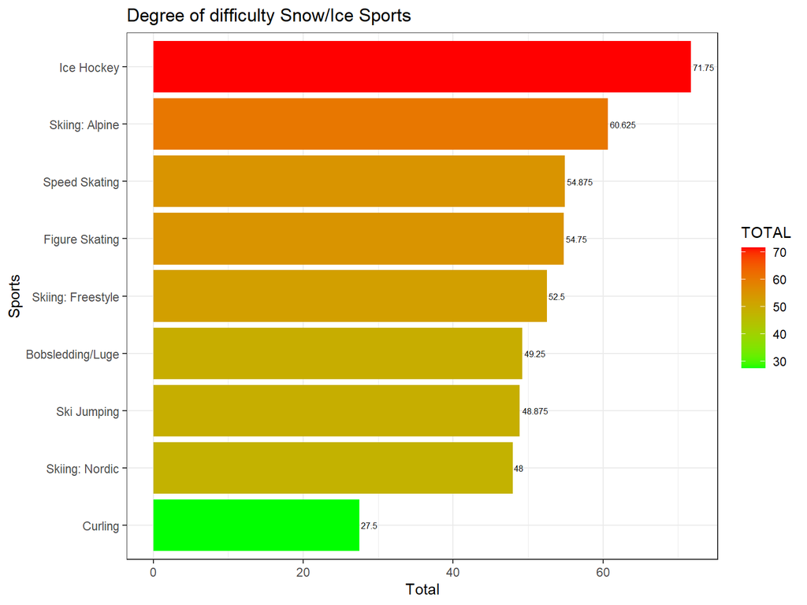

```
## # A tibble: 1 × 3
##   `max(TOTAL)` `min(TOTAL)` `mean(TOTAL)`
##          <dbl>        <dbl>         <dbl>
## 1         71.8         27.5          52.0
```

# Toughest Adventure Sports

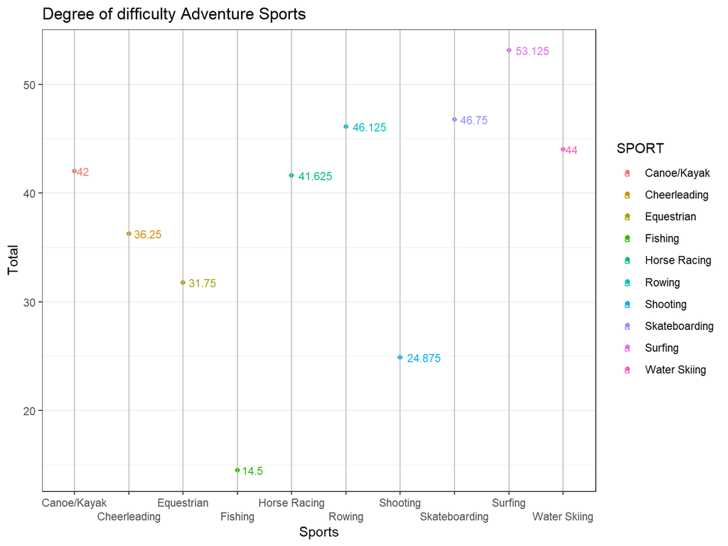

```
## # A tibble: 1 × 3
##   `max(TOTAL)` `min(TOTAL)` `mean(TOTAL)`
##          <dbl>        <dbl>         <dbl>
## 1         53.1         14.5          38.1
```

# Toughest Water Sports

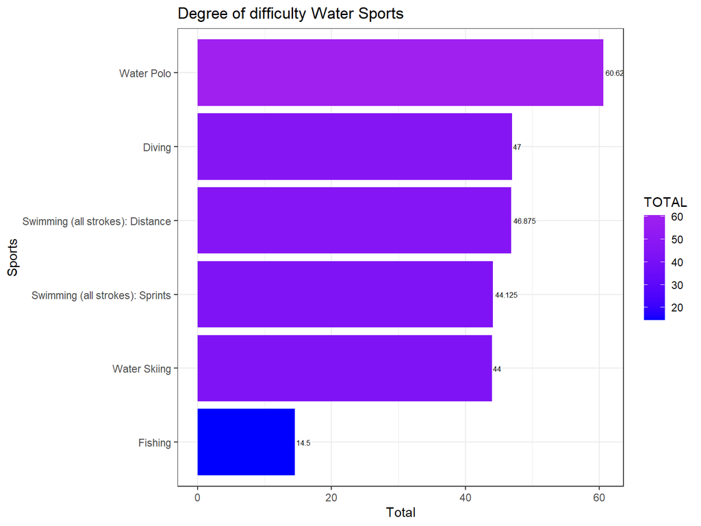

```
## # A tibble: 1 × 3
##   `max(TOTAL)` `min(TOTAL)` `mean(TOTAL)`
##          <dbl>        <dbl>         <dbl>
## 1         60.6         14.5          42.9
```

# Toughest Team Sport

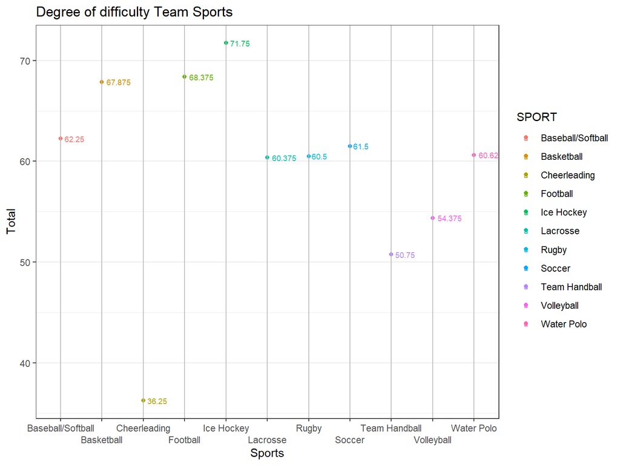

```
## # A tibble: 1 × 3
##   `max(TOTAL)` `min(TOTAL)` `mean(TOTAL)`
##          <dbl>        <dbl>         <dbl>
## 1         71.8         36.2          59.5
```

# Toughest Individual Sport

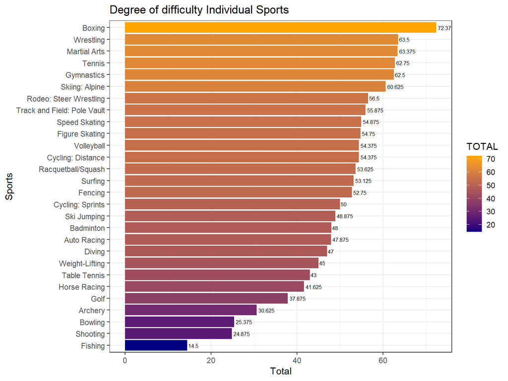

```
## # A tibble: 1 × 3
##   `max(TOTAL)` `min(TOTAL)` `mean(TOTAL)`
##          <dbl>        <dbl>         <dbl>
## 1         72.4         14.5          49.3
```

# Which skill has the highest overrall total aganist one another

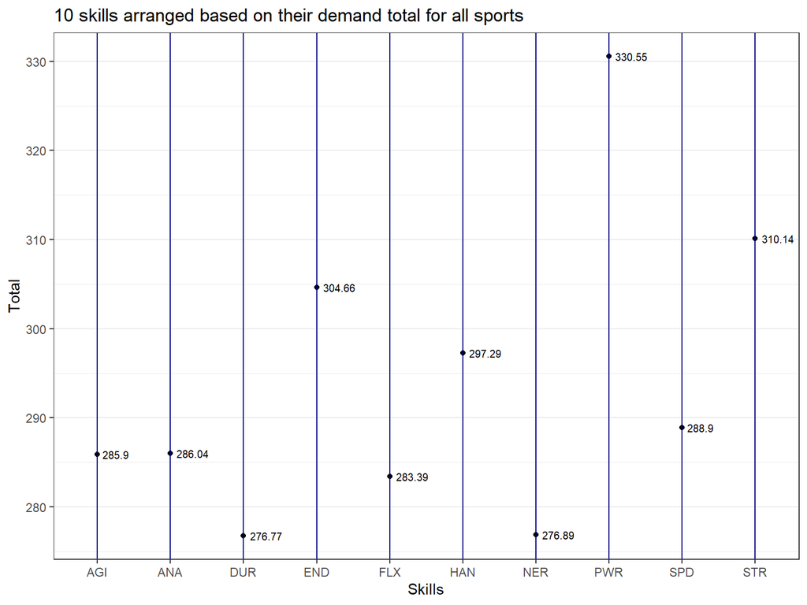

The data collected here is the sum total for each skill.

According to the graph, power (PWR) is considered the most or highest utilized skill in all 60 sports. Durability (DUR) however, is considered the least utilized skill based on the total demand for each sport.

- Side note: The y-axis,(Total) starts at 275 and not a baseline at zero b/c were trying to display the data more precisely. All total amounts are above 275.

# Conclusion

- In conclusion, we can determine that the data-set reveals that out of 60 sports. Boxing is considered the most difficult sport and fishing is more effortless based on their total amount of difficulty based on 10 skills ranked 1-10. Each skill differentiates and presents a range of difficulty for each sport. Team sports seemed to be more competitive and difficult compared to individual sports, based on their mean total.